# Python for Climate & Water Professionals

Installing Python & Environment Management

Yonas M.

2023-03-06

# Installing Python

When installing Python on your machine, you have the option to install it **system-wide** or in a **virtual environment**.

## System-wide Installation

Installing Python system-wide may seem like the most straightforward approach, it can lead to several problems:

- **Dependency conflicts**: Installing packages system-wide can result in dependency conflicts with other packages installed on the system, which can lead to unexpected behavior.
- **Version conflicts**: Different projects may require different versions of the same package, which can be difficult to manage when installing packages system-wide.
  - E.g, you may have two projects: one using pandas-0.25 and the other pandas-1.5. You cannot install both versions system-wide,

## Isolated Installation

Installing Python in a **virtual environment** provides several benefits:

- **Isolation**: Virtual environments provide an isolated environment for each project, which means that any changes made to one project will not affect the other projects running on the same machine.
- **Dependency management**: Virtual environments allow you to manage project dependencies easily, without conflicting with system dependencies or other projects on the same machine.
- **Reproducibility**: Virtual environments ensure that your project can be easily replicated on another machine with the same dependencies and versions.
- **Flexibility**: Virtual environments allow you to experiment with different versions of packages and libraries.

# Windows-10 Subsystem for Linux (WSL) installation

**Linux**-based operating systems offer many benefits for **computational tasks** and are often the preferred choice for researchers and developers in fields such as **scientific computing**, **data analysis**, and **machine learning**.

Recently, Windows users who need to run Linux-based tools and software on their Windows machines can use the **Windows 10 Subsystem for Linux (WSL)**.

It allows users to run Linux distros such as Ubuntu, Debian, CentOS, and Mint on Windows-10.

WSL does not require any **virtualization** and much **memory** that makes it super useful.

It enables users to explore the benefits of Linux alongside Windows without losing Windows OS.

The following steps can be used to install WSL on Windows:

Step:1 Enabling Windows Subsystem for Linux:

- From the start menu open windows Settings

[figure not shown]

- From windows settings, select **Apps**

[figure not shown]

- In the **Apps & features tab**, under the **Related settings** section select **Programs and Features** option

[figure not shown]

- Now click on the **Turn Windows features on or off** option

[figure not shown]

- Check the **Windows Subsystem for Linux** option & click **OK** button

[figure not shown]

- Click the Restart tab

[figure not shown]

Step:2 Installing Ubuntu Linux distro from Microsoft Store:

- Open Microsoft Store from the start menu

[figure not shown]

- In the search bar type **Ubuntu** & select either **Ubuntu 18.04** LTS or **Ubuntu 20.04** LTS

[figure not shown]

- Then, click on **Get** or **Install button**, this may take a while to complete

[figure not shown]

- When the installation completed, click the **Launch** button
- The ubuntu terminal will open & you will be asked to wait for a few minutes to complete the remaining installation
  - Then, you will be asked to create a **user account** & **password**
  - Type **username** & press **Enter**, then type a **new password** & press **Enter**
  - Repeat the password & press Enter to confirm

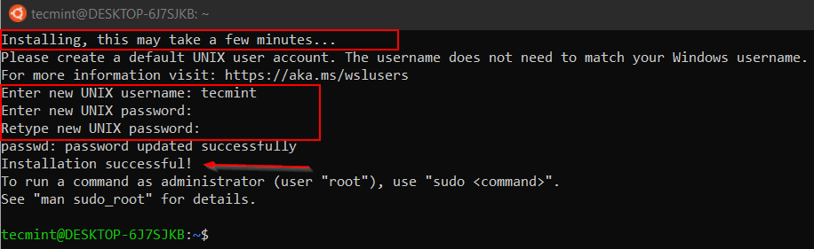

# Anaconda

- **Anaconda** is a distribution (collection of programs) of Python, R, and other languages for scientific computing that aims to simplify **package management** and **deployment**.
- It offers its own **package manager** and **environment management** called **conda**.
- Conda is an open-source and cross-platform (Windows, Mac OS and Linux) package manager.
- Conda easily installs and updates packages, and switches between environments.
- It provides multiple channels to install packages. Channels are locations where packages are stored (E.g. defaults, conda-forge, bioconda)
- It provides several python packages, libraries, and IDE/editors.
- It doesn’t always have the most up-to-date packages (downside).
- When you install Anaconda you get Python, R, plus 250 pre-installed packages.
- It can be used with either the conda **command-line** tool or the **Anaconda Navigator desktop GUI**.

# Install Anaconda on Lunix OS

- This tutorial will walk you through the installation of Anaconda on an Lunix system (Ububtu).
- For more information on installation: https://docs.anaconda.com/anaconda/install/linux/

Step: 1 Update the ubuntu package manager:

Open the terminal & enter the following:

```
sudo apt-get update
```

Step: 2 To use desktop GUI called Anaconda Navigator the following packages must be installed:

```
sudo apt-get install libgl1-mesa-glx libegl1-mesa libxrandr2 libxrandr2 libxss1 libxcursor1 libxcomposite1 libasound2 libxi6 libxtst6
```

Step: 3 Installing **Wget** package in order to easily download the Anaconda package:

**Wget** package is primarily used for downloading data & files using HTTP, HTTPS, & FTP protocols from various servers. In this case, we’ll use wget to download the Anaconda package.

Let’s begin by installing the wget package:

```
sudo apt-get install -y wget
```

Once installation finished check its version by running:

```
wget --version
```

Step: 4 Download the anaconda installation script via wget:

First, move to the /tmp directory to place the script file

```
cd /tmp
```

Then, download the Anaconda installation script, it may take some time

```
wget -P /tmp https://repo.anaconda.com/archive/Anaconda3-2020.02-Linux-x86_64.sh
```

You may get the latest info @ https://www.anaconda.com/products/distribution

Step: 5 Verify the downloaded script via `sha256sum` command:

```
sha256sum /tmp/Anaconda3–2020.02–Linux–x86_64.sh
```

You should see an output that looks similar to this:

```
2b9f088b2022edb474915d9f69a803d6449d5fdb4c303041f60ac4aefcc208bb /tmp/Anaconda3-2020.02-Linux-x86_64.sh
```

Step: 6 Begin the installation process by running the following command:

```
bash /tmp/Anaconda3-2020.02-Linux-x86_64.sh
```

You should see an output like the following:

```
Welcome to Anaconda3 2020.02

In order to continue the installation process, please review the license agreement.
Please, press ENTER to continue
```

Continue by pressing until you are prompted to accept the license terms:

Do you approve the license terms? [yes,no]

```
yes
```

Accept the license agreement by typing **yes**, then **ENTER**.

You’ll be prompted to select an **installation location** & you should see an output like the following:

Anaconda3 will now be installed into this location: **/home/user/anaconda3**

Press ENTER to confirm the location  
Press CTRL-C to abort the installation  
Or specify a different location below  
Confirm the location by press

```
Confirm the location by press <ENTER>
```

Step: 7 Adding Conda command-line: Next, you’ll be asked if you want to run **conda init**, type **yes** & press **ENTER**

This will add conda command-line tool to your system PATH

Step: 8 Activate Anaconda: To activate the Anaconda installation:

```
source ~/.bashrc
```

You have now successfully installed Anaconda on your system

# Install Anaconda on Windows OS

Step 1: Download the latest Anaconda installer from https://www.anaconda.com/products/distribution

Step 2: Go to your Downloads folder and double-click the installer to launch.

Step 3: Click Next.

Step 4: Read the licensing terms and click I Agree.

- It is recommended that you install for Just Me, which will install Anaconda Distribution to just the current user account.

Step 5: Click Next.

Step 6: Select a destination folder to install Anaconda and click Next.

- Install Anaconda to a directory path that does not contain spaces or unicode characters.

[figure not shown]

- Do not install as Administrator unless admin privileges are required.
- Do not add Anaconda to your PATH environment variable, since this can interfere with other software.

[figure not shown]

Step 7: Click Install and Next

Step 8: After a successful installation you will see the “Thanks for installing Anaconda” dialog box:

[figure not shown]

For further information: https://docs.anaconda.com/anaconda/install/windows/

# Miniconda

- **Miniconda** is another Python distribution and it contains just a few pre-installed packages (It is a lightweight version of Anaconda).
- It incorporates the package manager conda
- You should use it if you want to install all the necessary packages yourself using the command line.
- You don’t want to waste disk space for packages you won’t use.
- Mainly if you are very experienced with the command line.
- Miniconda has additional package manager and environment management called **Mamba**.
- Mamba is rewritten on C++, so it’s faster and uses less computing resources.
- It uses the same syntax as conda you just have to change conda to mamba.

To install Mamba:

```
conda install -c conda-forge mamba
```

or

```
conda install mamba -n base -c conda-forge
```

# Install Miniconda on Lunix OS

Step 1: Create a directory to install miniconda into

```
mkdir -p ~/miniconda3
```

Step 2: Download the latest python 3 based install script for Linux 64 bit

```
wget https://repo.anaconda.com/miniconda/Miniconda3-latest-Linux-x86_64.sh -O ~/miniconda3/miniconda.sh
```

Step 3: Run the install script

```
bash ~/miniconda3/miniconda.sh -b -u -p ~/miniconda3
```

- b: to be able to run unattended, which means that all of the agreements are automatically accepted without user prompt.
- u: updates any existing installation in the directory of install if there is one.
- p: is the directory to install into.

Step 4: Delete the install script

```
rm -rf ~/miniconda3/miniconda.sh
```

Step 5: Add a conda initialize to your bash or zsh shell

```
~/miniconda3/bin/conda init bash
~/miniconda3/bin/conda init zsh
```

# Uninstalling Anaconda or Miniconda

- In the terminal, you can write out the following command to remove Anaconda from your system:

```
rm -rf ~/anaconda3
```

- In the terminal, you can write out the following command to remove miniconda from your system:

```
rm -rf ~/miniconda
```

- OPTIONAL: Edit *~/.bash_profile* to remove the Anaconda/Miniconda directory from your PATH environment variable.
- OPTIONAL: Remove the following hidden file and folders that may have been created in the home directory:

```
rm -rf ~/.condarc ~/.conda ~/.continuum
```

# Python Environment management with Conda

**Environment** is a directory that contains a specific collection of packages/tools that you have installed.

[figure not shown]

Starting conda:

- Windows: From the Start menu, search for and open Anaconda Prompt
- Linux: open a terminal window.

Verify that conda version by typing:

```
conda --version
```

Update conda to the current version. Type the following:

```
conda update conda

conda update -n base -c defaults conda
```

If a newer version of conda is available, type y to update:

```
Proceed ([y]/n)? y
```

**Managing environments**

Conda allows you to create separate environments containing files, packages, and their dependencies that will not interact with other environments.

```
conda create --name environment_name packages_name
conda create --name pythonv27 python=2.7
conda create --name pythonv27 python
```

To use or activate the new environment, type the following:

```
conda activate environment_name
conda activate pythonv27
```

The active environment is the one with an asterisk (*).

Removing an environment

```
conda env remove --name environment_name
conda env remove --name pythonv27
conda env remove -n pythonv27
```

Example 1: CDO

```
conda create --name cdo_env
conda activate cdo_env
conda install -c conda-forge cdo
```

Example 2: NCL

```
conda create --name ncl_env
conda activate ncl_env
conda install -c conda-forge ncl
```

To see a list of all your environments, type:

```
conda info --envs
conda env list
```

To install package into the current environment:

```
conda install packages_name
conda install python=3.5
```

This is the location where Python packages can be found: https://anaconda.org/anaconda

To find a package you have already installed:

```
conda search packages_name
conda search python
```

To uninstall package:

```
conda uninstall packages_name
conda search python
```

To update package:

```
conda update packages_name
conda update python
```

To list all installed packages in this environment:

```
conda list
```

Exiting an environment

```
conda deactivate
```

Sharing an environment

- You may want to share your environment with someone else, so that they can re-create your project.
- To allow them to quickly reproduce your environment, with all of its packages and versions, give them a copy of your **environment.yml** file.
- Step 1: Activate the environment to export:

```
conda activate myenv
```

- Step 2: Export the environment

```
conda env export > environment.yml
conda env export --from-history > environment.yml
```

- Step 3: Create the environment from the environment.yml file:

```
conda env create -f environment.yml
```

EXAMPLE: environment.yml file:

```
name: stats2
channels:
  - javascript
dependencies:
  - python=3.9
  - bokeh=2.4.2
  - conda-forge::numpy=1.21.*
  - nodejs=16.13.*
  - flask
  - pip
  - pip:
    - Flask-Testing
```

# Interactive Environments: Jupyter Notebooks

Why Jupyter Notebooks ?

- **Interactive computing**: It allow for interactive computing, where users can *write*, *execute*, and *modify* code in *real-time*. This makes it easy to experiment with different algorithms and models, visualize data, and explore results.
- *Documentation*: It enable users to document their work using a combination of *code*, *text*, and other formats. This makes it easy to share results, collaborate with others, and reproduce experiments.
- *Reproducibility*: It provide a platform for creating *reproducible workflows,* where all the *code* and *data* required to reproduce an experiment or analysis are contained within the notebook. This makes it easier to verify results, share work with others, and build on existing research.
- *Flexibility*: It support a wide range of programming languages, including *Python*, *R,* and *Julia*, making it easy to work with different tools and libraries.
- *Data visualization*: It support various data visualization libraries and tools, which makes it easy to create *charts,* *graphs*, and o*ther visualizations* to explore and communicate data.
- *Collaboration*: It support collaboration between multiple users, enabling teams to work on a single project or analysis. Users can share notebooks, add comments, and collaborate on code, making it easier to work together and share knowledge.
- *Education*: Jupyter notebooks are widely used in education, providing a platform for teaching and learning programming, data analysis, and machine learning. They enable instructors to provide interactive, *hands-on learning experiences* that engage students and reinforce key concepts.

# Installing Jupyter Notebooks

Activate the environment in which you are working.

```
conda activate myenv
```

Install the classic Jupyter Notebook with:

```
pip install notebook
```

To run the notebook:

```
jupyter notebook
```

Install Jupyter Notebook via Conda

```
conda install -c conda-forge notebook
conda install -c conda-forge nb_conda_kernels
```

Installing Jupyter Notebook extensions

```
conda install -c conda-forge jupyter_contrib_nbextensions
```